# Bank Churn Prediction

**Explore the relationship between numerical features and Exited**

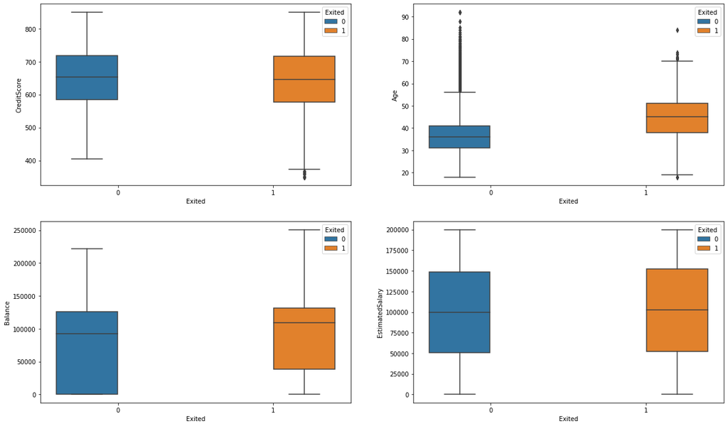

```python
    fig, graph_array_1 = plt.subplots(2, 2, figsize=(20, 12))
    sns.boxplot(y='CreditScore',x = 'Exited', hue = 'Exited',data = df, ax=graph_array_1[0][0])
    sns.boxplot(y='Age',x = 'Exited', hue = 'Exited',data = df , ax=graph_array_1[0][1])
    sns.boxplot(y='Balance',x = 'Exited', hue = 'Exited',data = df, ax=graph_array_1[1][0])
    sns.boxplot(y='EstimatedSalary',x = 'Exited', hue = 'Exited',data = df, ax=graph_array_1[1][1])
```

Lets look at the pairplot

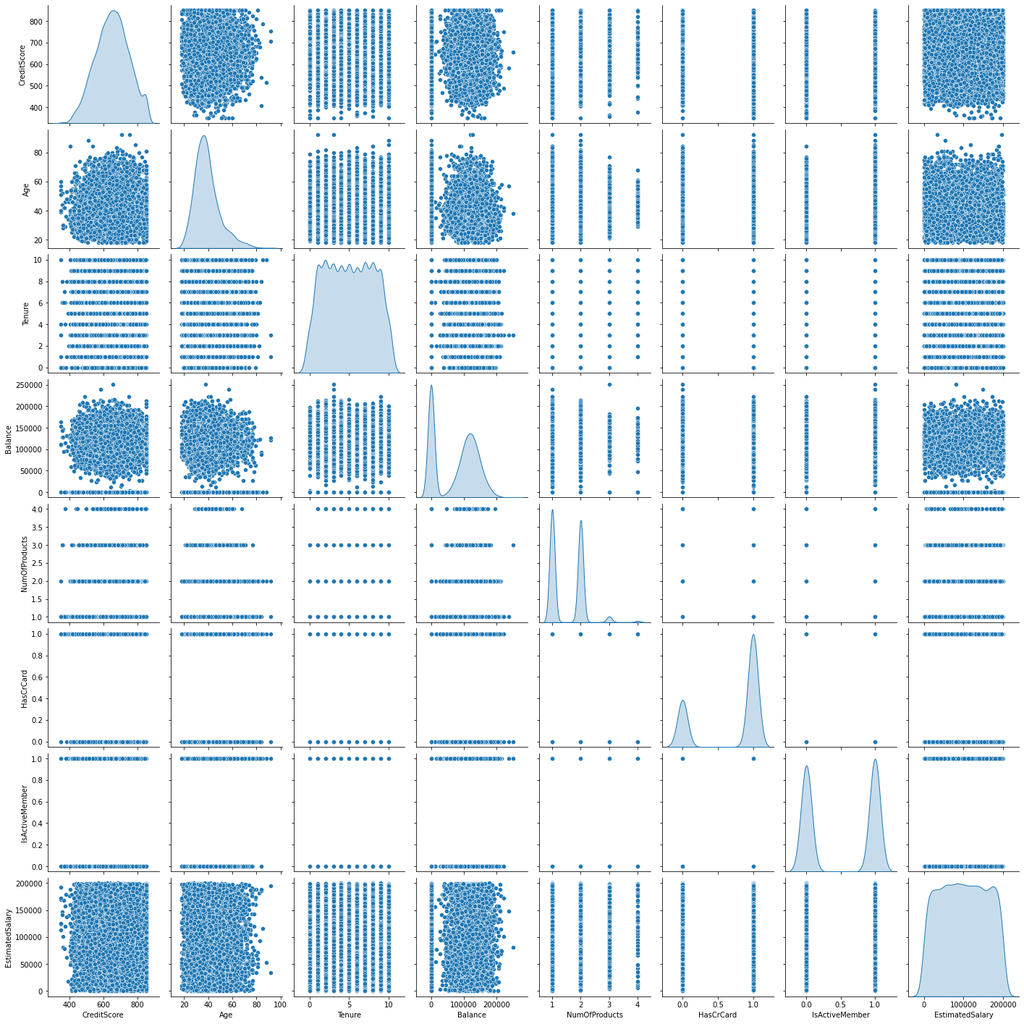

```python
sns.pairplot(X, diag_kind='kde')
```

**Encode categoriacal variables**

Gender and Geography attributes need to be encoded. Let's use LabelEncoder for this process

```python
gender_encoder = LabelEncoder()
X['Gender'] = gender_encoder.fit_transform(X['Gender'])
```

```python
geography_encoder = LabelEncoder()
X['Geography'] = geography_encoder.fit_transform(X['Geography'])
X = pd.get_dummies(X, drop_first=True, columns=['Geography'])
X.head()
```

|  | CreditScore | Gender | Age | Tenure | Balance | NumOfProducts | HasCrCard | IsActiveMember | EstimatedSalary | Geography_1 | Geography_2 |
| --- | --- | --- | --- | --- | --- | --- | --- | --- | --- | --- | --- |
| 0 | 619 | 0 | 42 | 2 | 0.00 | 1 | 1 | 1 | 101348.88 | 0 | 0 |
| 1 | 608 | 0 | 41 | 1 | 83807.86 | 1 | 0 | 1 | 112542.58 | 0 | 1 |
| 2 | 502 | 0 | 42 | 8 | 159660.80 | 3 | 1 | 0 | 113931.57 | 0 | 0 |
| 3 | 699 | 0 | 39 | 1 | 0.00 | 2 | 0 | 0 | 93826.63 | 0 | 0 |
| 4 | 850 | 0 | 43 | 2 | 125510.82 | 1 | 1 | 1 | 79084.10 | 0 | 1 |

**Data Split**

```python
# Let's split the train and test data
X_train, X_test, y_train, y_test = train_test_split(X, y, test_size = 0.2, random_state = 7, stratify = y)
```

**Normalization**

Let's apply normalize and StandardScalar to look at the accuracy of the model

```python
#X_train = preprocessing.normalize(X_train)
#X_test = preprocessing.normalize(X_test)
```

Normalzied data produced accuracy of 0.796

```python
scaler = StandardScaler()
X_train = scaler.fit_transform(X_train)
X_test = scaler.transform(X_test)
```

```python
print(X_train.shape)
print(X_test.shape)
print(y_train.shape)
print(y_test.shape)
```

```
(8000, 11)
(2000, 11)
(8000,)
(2000,)
```

**Model Building**

```python
model = Sequential()
model.add(Dense(X.shape[1], activation='relu', input_dim = X.shape[1]))
model.add(Dense(32, activation='relu'))
model.add(Dense(1, activation = 'sigmoid'))
```

Compile model with Optimzier and loss function

```python
sgd = optimizers.Adam(lr = 0.001)
```

```python
model.compile(optimizer = sgd, loss = 'binary_crossentropy', metrics=['accuracy'])
```

```python
model.summary()
```

```
Model: "sequential"
_________________________________________________________________
Layer (type)                 Output Shape              Param #
=================================================================
dense (Dense)                (None, 11)                132
_________________________________________________________________
dense_1 (Dense)              (None, 32)                384
_________________________________________________________________
dense_2 (Dense)              (None, 1)                 33
=================================================================
Total params: 549
Trainable params: 549
Non-trainable params: 0
_________________________________________________________________
```

```python
model.fit(X_train, y_train.values, batch_size = 100, epochs = 100, verbose = 1)
```

```
Train on 8000 samples
```

```
<tensorflow.python.keras.callbacks.History at 0x7fd521089390>
```

```python
results = model.evaluate(X_test, y_test.values)
```

```python
print(model.metrics_names)
print(results)
```

```
['loss', 'accuracy']
[0.3516337722539902, 0.8605]
```

```python
Y_pred_cls = model.predict_classes(X_test, batch_size=200, verbose=0)
print('Accuracy Model1 (Dropout): '+ str(model.evaluate(X_test,y_test.values)[1]))
print('Recall_score: ' + str(recall_score(y_test.values,Y_pred_cls)))
print('Precision_score: ' + str(precision_score(y_test.values, Y_pred_cls)))
print('F-score: ' + str(f1_score(y_test.values,Y_pred_cls)))
confusion_matrix(y_test.values, Y_pred_cls)
```

```
Accuracy Model1 (Dropout): 0.8605
Recall_score: 0.4987714987714988
Precision_score: 0.7302158273381295
F-score: 0.5927007299270073
```

```
array([[1518,   75],
       [ 204,  203]])
```

```python
y_pred = model.predict_classes(X_test)
accuracy_score(y_test, y_pred)
```

```
0.8605
```